# Método de los k- vecinos más próximos (KNN)

Grupo: Far Away

05 de Mayo de 2024

| Integrantes |  |
| --- | --- |
| Burgos Flaqué, María Fernanda | fernandaburgosflaque@gmail.com |
| Coronel, Yesica Sidanelia | yesicacoronel.cpn@gmail.com |
| Francomano, Pablo Nicolás | pablo.francomano@gmail.com |
| Maccari, Pablo Augusto | pablomaccari@hotmail.com |
| Pipinich, Joaquin | joaquinpipinich@gmail.com |

## Kesimo Vecino Más Próximo (KNN)

### Análisis de caso

#### Introducción

El método de los Kesimos vecinos mas cercanos es una técnica de agrupamiento mediante la cual los datos analizados son asignados a cierta cantidad de grupos, dependientes de un valor k. La asignación de cada registro a cada cluster se ejecuta basándose en la distancia al centroide más cercano. Esta agrupación permite la clasificación de nuevos datos o casos, permitiendo llegar a conclusiones según el grupo al que sean asignados.

El siguiente trabajo busca utilizar este método para poder predecir en que tipo de actividad industrial o comercial se ubica una empresa de la cual solo se conocen dos variables: riesgo y rentabilidad.

#### Hipótesis

Se puede estimar dentro de que 5 actividades se encuentra una empresa cualquiera (llamada A) conociendo su riesgo y su rentabilidad.

#### Desarrollo del método KNN

##### Paso 1. Carga de datos y primer análisis

El primer paso para el análisis del caso mencionado consiste en la carga de un set de 254 datos de riesgo- rentabilidad, para empresas de Mendoza.

```r
library(readr)
datos <- read_delim("https://themys.sid.uncu.edu.ar/rpalma/R-cran/Frontera_Pareto.csv",
    ";", escape_double = FALSE, locale = locale(decimal_mark = ",",
        grouping_mark = "|"), trim_ws = TRUE)
```

```
## `curl` package not installed, falling back to using `url()`
##
```

Como muestra, se imprimen las primeras filas a continuación.

```r
head(datos)
```

```
## # A tibble: 6 × 2
##   Riesgo Rentabilidad
##    <dbl>        <dbl>
## 1  0.230         36.2
## 2  0.139         36.4
## 3  0.155         36.7
## 4  0.235         37.1
## 5  0.235         37.7
## 6  0.362         36.2
```

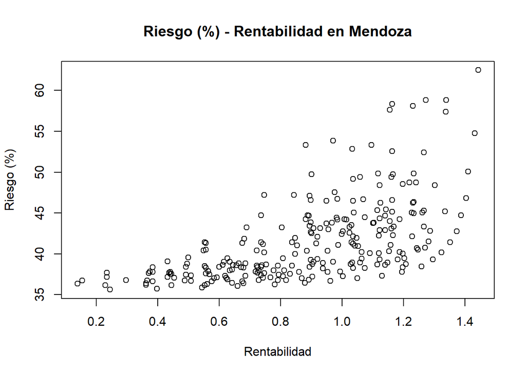

```r
my <- datos$Rentabilidad
mx <- datos$Riesgo

plot(mx,my,type="p", main="Riesgo (%) - Rentabilidad en Mendoza",ylab="Riesgo (%)",xlab="Rentabilidad")
```

La grafica muestra una relación creciente entre ambas variables, a mayor riesgo parece haber mayor rentabilidad para la mayoría de los casos y viceversa.

##### Paso 2. Generación de clusters

```r
set.seed(123)
library(cluster)
fit <- kmeans(datos, 5)
fit
```

```
## K-means clustering with 5 clusters of sizes 54, 53, 14, 105, 28
##
## Cluster means:
##      Riesgo Rentabilidad
## 1 0.9434583     40.31409
## 2 1.0620127     43.74186
## 3 1.1985407     56.04491
## 4 0.6755260     37.52853
## 5 1.1075578     47.95315
##
## Clustering vector:
##   [1] 4 4 4 4 4 4 4 4 4 4 4 4 4 4 4 4 4 4 4 4 4 4 4 4 4 4 4 4 4 4 4 4 4 4 4 4 4
##  [38] 4 4 1 4 4 4 4 4 4 1 4 4 4 4 4 4 4 4 4 4 1 1 1 1 4 4 4 4 4 4 4 4 4 4 4 4 4
##  [75] 4 4 4 4 4 4 4 4 4 4 4 4 4 4 1 1 1 1 1 1 1 1 4 4 4 4 1 1 4 1 4 1 1 4 4 1 1
## [112] 1 1 1 2 2 2 2 2 2 2 2 2 2 2 2 2 1 1 1 1 1 1 1 1 1 1 1 2 2 2 2 2 5 5 5 5 5
## [149] 5 5 5 2 2 2 2 2 2 1 2 5 2 2 1 3 3 5 5 5 3 5 5 5 3 3 3 5 5 5 5 5 3 3 3 3 3
## [186] 5 2 5 2 2 2 5 5 2 2 2 2 2 2 2 2 2 2 2 2 2 2 1 1 1 1 1 1 1 1 4 4 4 4 1 1 1
## [223] 1 1 1 2 2 2 2 2 5 2 5 3 4 4 4 4 4 4 4 4 4 4 4 1 1 1 2 2 5 5 3 3
##
## Within cluster sum of squares by cluster:
## [1]  48.77914  52.30852 127.64933  82.01858  49.56641
##  (between_SS / total_SS =  94.5 %)
##
## Available components:
##
## [1] "cluster"      "centers"      "totss"        "withinss"     "tot.withinss"
## [6] "betweenss"    "size"         "iter"         "ifault"
```

##### Paso 3. Asignación de nombres para los clusters

A continuación se le asigna un nombre a cada uno de los clusters. Para ello se utiliza la denominación “Group_N” donde N representa un número secuencial. Se podrían también asignar palabras o rubros que faciliten el análisis.

```r
set.seed(123)
aggregate(datos,by=list(fit$cluster),FUN=mean)
```

```
##   Group.1    Riesgo Rentabilidad
## 1       1 0.9434583     40.31409
## 2       2 1.0620127     43.74186
## 3       3 1.1985407     56.04491
## 4       4 0.6755260     37.52853
## 5       5 1.1075578     47.95315
```

```r
mi_cluster <- data.frame(datos, fit$cluster)
```

Se puede obtener a continuación la asignacion de cada dato de la problación a cada el cluster en función de riesgo y rentabilidad.

```r
mi_cluster
```

```
##        Riesgo Rentabilidad fit.cluster
## 1   0.2299914     36.17758           4
## 2   0.1392425     36.35505           4
## 3   0.1547155     36.71515           4
## 4   0.2348895     37.14919           4
## 5   0.2348895     37.67857           4
## 6   0.3618077     36.18910           4
## 7   0.4453633     36.17758           4
## 8   0.3618077     36.37949           4
## 9   0.3842360     36.62135           4
## 10  0.3663192     36.74245           4
## 11  0.2972553     36.75617           4
## 12  0.5527457     36.16610           4
## 13  0.5606940     36.30674           4
## 14  0.5082500     36.70159           4
```

[output cut: 240 more lines]

##### Paso 4. Analisis de componenetes prinicpales (PCA)

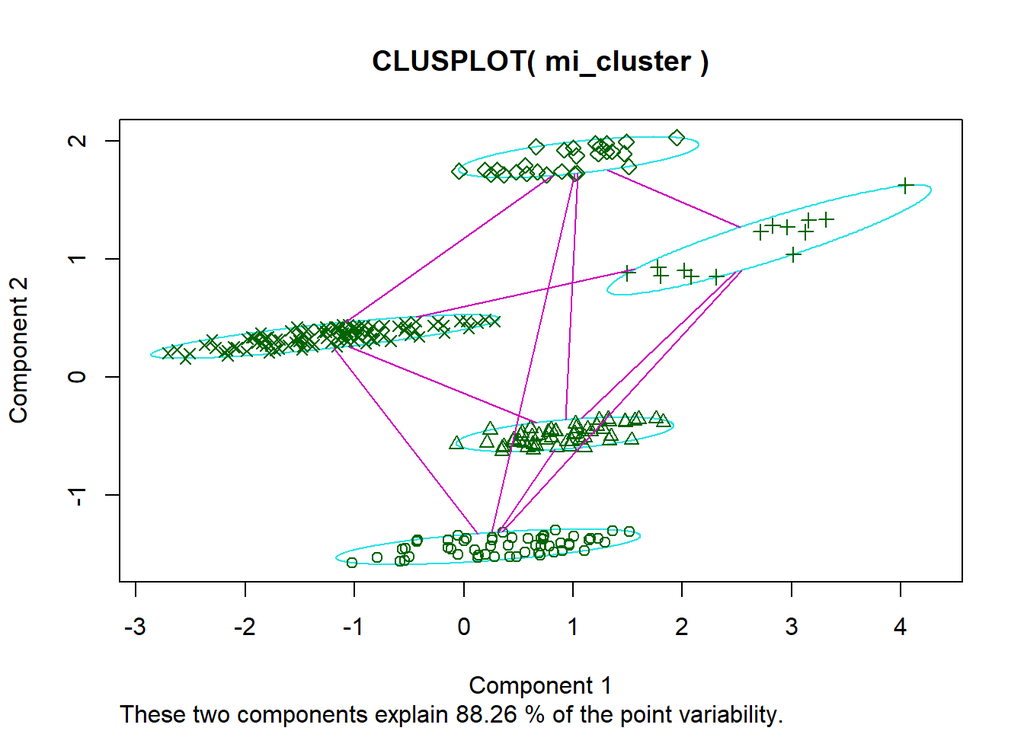

```r
clusplot(mi_cluster,mi_cluster$fit.cluster)
```

El análisis de componentes principales es técnica estadística de síntesis de la información, o reducción de la dimensión (número de variables). En el caso analizado se utiliza para entender cuan bien explican las dos variables seleccionadas el comportamiento de las empresas. Para este ejemplo, las variables riesgo y rentabilidad explican el 88.26%. Es interesante mencionar que si este valor fuera menor al 50% deberían agregarse mas variables a los datos iniciales y repetir los pasos ya mencionados.

##### Paso 5.Grafica de asignaciones (clusters)

Al graficar nuevamente los datos, pero esta vez diferenciando por color la asignación a cada cluster, se observa la misma relación entre las dos variables analizadas pero esta vez con división por actividad (clusters).

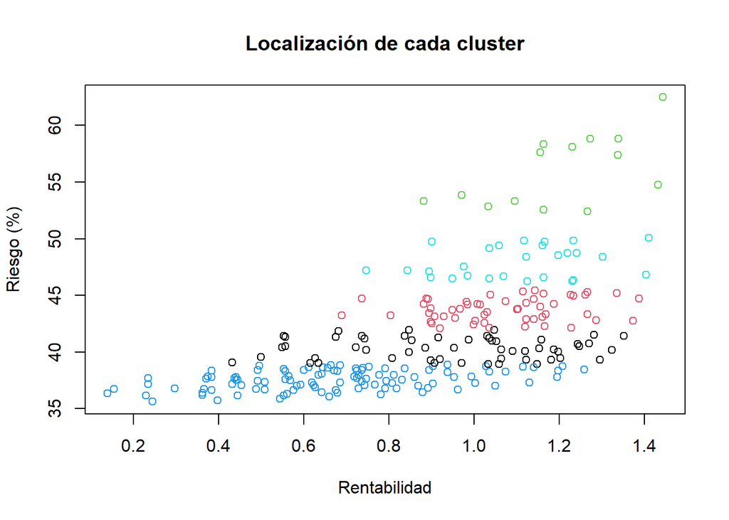

```r
plot(mi_cluster$Riesgo , mi_cluster$Rentabilidad , col=mi_cluster$fit.cluster, main = "Localización de cada cluster",ylab="Riesgo (%)",xlab="Rentabilidad")
```

##### Paso 5. Entrenamiento KNN

El entrenamiento de un modelo de vecino próximo puede ser una buena opción cuando la población es muy grande. Es como trabajar con una muestra de la población. Para el análisis de este caso se tiene conocimiento de a qué actividad pertenece cada una de las empresas que fueron encuestadas sobre riesgo percibido de sus actividad y rentabilidad.

```r
train <- mi_cluster
cl  <- factor(mi_cluster$fit.cluster, levels = c("1", "2","3","4","5"),labels = c("Prost, Penalist, Casino","Bank, Cred_pers, Tel_Cel, Bebidas", "Manufactura, Metal_Mec, Servicios ,Seguros,Bodegas","MOA, Restaurant, Emprendimientos BT","Transporte, Pasajeros, Indumentaria, Perecederos"))
```

```r
summary(cl)
```

```
##                            Prost, Penalist, Casino
##                                                 54
##                  Bank, Cred_pers, Tel_Cel, Bebidas
##                                                 53
## Manufactura, Metal_Mec, Servicios ,Seguros,Bodegas
##                                                 14
##                MOA, Restaurant, Emprendimientos BT
##                                                105
##   Transporte, Pasajeros, Indumentaria, Perecederos
##                                                 28
```

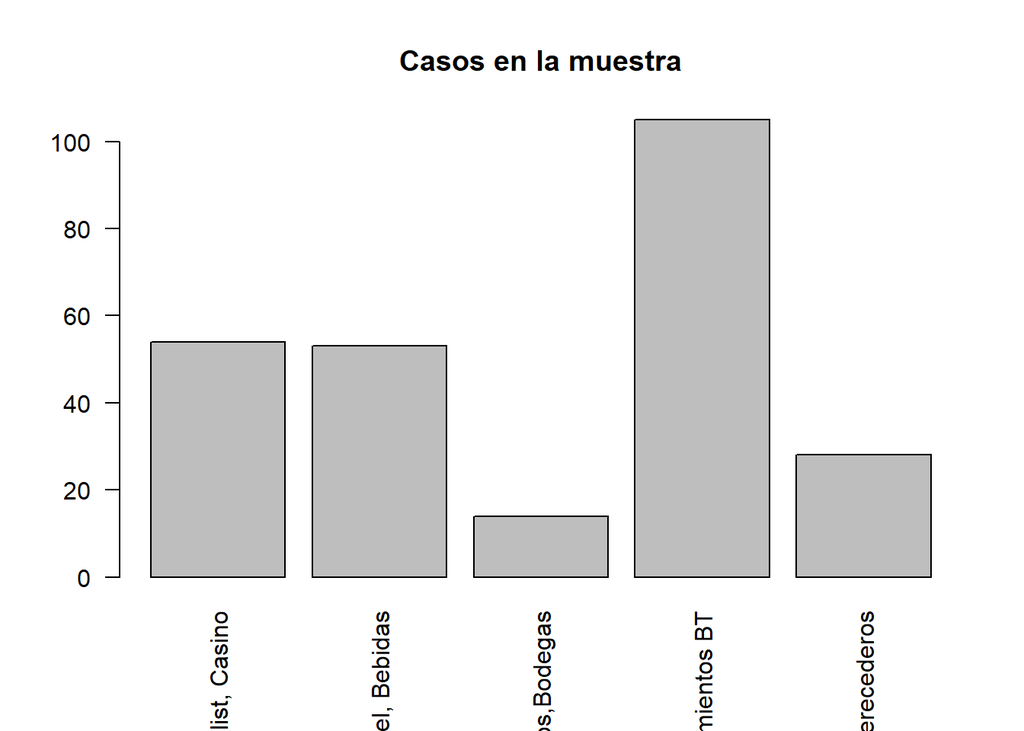

```r
plot(cl, main="Casos en la muestra", las = 2)
```

#### Caso de estudio e interpretación de resultados

Teniendo los datos de rentabilidad y riesgo de una empresa A, se busca conocer a que tipo de actividad pertenece, segun su asignación a un cluster.

```r
mi_caso <- cbind (50,62.23,3 )
mi_caso
```

```
##      [,1]  [,2] [,3]
## [1,]   50 62.23    3
```

A continuación se analiza a que cluster pertenecen los 20 vecinos más próximos.

```r
set.seed(123)
library(class)
knn(train, mi_caso, k=20, cl, prob=TRUE)
```

```
## [1] Manufactura, Metal_Mec, Servicios ,Seguros,Bodegas
## attr(,"prob")
## [1] 0.7
## 5 Levels: Prost, Penalist, Casino ... Transporte, Pasajeros, Indumentaria, Perecederos
```

- Manufactura
- Matalmecánica
- Servicios profesionales
- Agente de seguros
- Bodegas pequeñas

#### Conclusiones

El método de los k- vecinos mas próximos (KNN) es un método fácil de implementar, con pocos hiperparametros (valor k y métrica de distancia) y de fácil adaptación a nuevos datos. Para el tipo de análisis realizado en este trabajo es un método muy ventajoso, permitiendo obtener de manera rápida una buena estimación sobre el caso nuevo a analizar. Por otro lado, es un modelo muy propenso al sobre ajuste al ser tan relevante la elección del valor k.

#### Bibliografia

Vandeput, Nicolas. Data Science for Supply Chain Forecasting. Walter de Gruyter GmbH, 2021.

Grus, Joel. Data Science from Scratch. O´Reilly Media, 2015.

IBM, https://www.ibm.com/mx-es/topics/knn, (consultado el 5 de Mayo de 2024)